# Actividad 3: Regresión Lineal con Scikit-learn

**Dataset:** Real Estate (Realestate.csv)

**Objetivo:** Ajustar un modelo de regresión lineal múltiple para predecir el precio de una vivienda por unidad de área, y responder las preguntas del notebook usando la notación vista en clase:

$$Y = \beta_0 + \beta_1 X_1 + \beta_2 X_2 + \dots + \beta_p X_p + \varepsilon$$

## Importar librerías

```python
import pandas as pd
import numpy as np
import matplotlib.pyplot as plt
import seaborn as sns

from sklearn.model_selection import train_test_split
from sklearn.linear_model import LinearRegression
from sklearn import metrics

%matplotlib inline
sns.set_style('whitegrid')
```

## Explorar los datos

```python
df = pd.read_csv('Realestate.csv')
df.head()
```

|  | No | X1 transaction date | X2 house age | X3 distance to the nearest MRT station | X4 number of convenience stores | X5 latitude | X6 longitude | Y house price of unit area |
| --- | --- | --- | --- | --- | --- | --- | --- | --- |
| 0 | 1 | 2012.917 | 32.0 | 84.87882 | 10 | 24.98298 | 121.54024 | 37.9 |
| 1 | 2 | 2012.917 | 19.5 | 306.59470 | 9 | 24.98034 | 121.53951 | 42.2 |
| 2 | 3 | 2013.583 | 13.3 | 561.98450 | 5 | 24.98746 | 121.54391 | 47.3 |
| 3 | 4 | 2013.500 | 13.3 | 561.98450 | 5 | 24.98746 | 121.54391 | 54.8 |
| 4 | 5 | 2012.833 | 5.0 | 390.56840 | 5 | 24.97937 | 121.54245 | 43.1 |

```python
df.shape
```

```
(414, 8)
```

```python
df.info()
```

```
<class 'pandas.DataFrame'>
RangeIndex: 414 entries, 0 to 413
Data columns (total 8 columns):
 #   Column                                  Non-Null Count  Dtype
---  ------                                  --------------  -----
 0   No                                      414 non-null    int64
 1   X1 transaction date                     414 non-null    float64
 2   X2 house age                            414 non-null    float64
 3   X3 distance to the nearest MRT station  414 non-null    float64
 4   X4 number of convenience stores         414 non-null    int64
 5   X5 latitude                             414 non-null    float64
 6   X6 longitude                            414 non-null    float64
 7   Y house price of unit area              414 non-null    float64
dtypes: float64(6), int64(2)
memory usage: 26.0 KB
```

```python
df.describe()
```

|  | No | X1 transaction date | X2 house age | X3 distance to the nearest MRT station | X4 number of convenience stores | X5 latitude | X6 longitude | Y house price of unit area |
| --- | --- | --- | --- | --- | --- | --- | --- | --- |
| count | 414.000000 | 414.000000 | 414.000000 | 414.000000 | 414.000000 | 414.000000 | 414.000000 | 414.000000 |
| mean | 207.500000 | 2013.148971 | 17.712560 | 1083.885689 | 4.094203 | 24.969030 | 121.533361 | 37.980193 |
| std | 119.655756 | 0.281967 | 11.392485 | 1262.109595 | 2.945562 | 0.012410 | 0.015347 | 13.606488 |
| min | 1.000000 | 2012.667000 | 0.000000 | 23.382840 | 0.000000 | 24.932070 | 121.473530 | 7.600000 |
| 25% | 104.250000 | 2012.917000 | 9.025000 | 289.324800 | 1.000000 | 24.963000 | 121.528085 | 27.700000 |
| 50% | 207.500000 | 2013.167000 | 16.100000 | 492.231300 | 4.000000 | 24.971100 | 121.538630 | 38.450000 |
| 75% | 310.750000 | 2013.417000 | 28.150000 | 1454.279000 | 6.000000 | 24.977455 | 121.543305 | 46.600000 |
| max | 414.000000 | 2013.583000 | 43.800000 | 6488.021000 | 10.000000 | 25.014590 | 121.566270 | 117.500000 |

El dataset tiene 414 observaciones y 6 posibles variables predictoras ($X_1$ a $X_6$) más la variable respuesta $Y$, que es el precio de la vivienda por unidad de área. La columna `No` es solo un identificador de fila, así que no aporta información y la eliminaremos antes de modelar.

## Matriz de correlación

```python
df.drop(columns='No').corr()
```

|  | X1 transaction date | X2 house age | X3 distance to the nearest MRT station | X4 number of convenience stores | X5 latitude | X6 longitude | Y house price of unit area |
| --- | --- | --- | --- | --- | --- | --- | --- |
| X1 transaction date | 1.000000 | 0.017549 | 0.060880 | 0.009635 | 0.035058 | -0.041082 | 0.087491 |
| X2 house age | 0.017549 | 1.000000 | 0.025622 | 0.049593 | 0.054420 | -0.048520 | -0.210567 |
| X3 distance to the nearest MRT station | 0.060880 | 0.025622 | 1.000000 | -0.602519 | -0.591067 | -0.806317 | -0.673613 |
| X4 number of convenience stores | 0.009635 | 0.049593 | -0.602519 | 1.000000 | 0.444143 | 0.449099 | 0.571005 |
| X5 latitude | 0.035058 | 0.054420 | -0.591067 | 0.444143 | 1.000000 | 0.412924 | 0.546307 |
| X6 longitude | -0.041082 | -0.048520 | -0.806317 | 0.449099 | 0.412924 | 1.000000 | 0.523287 |
| Y house price of unit area | 0.087491 | -0.210567 | -0.673613 | 0.571005 | 0.546307 | 0.523287 | 1.000000 |

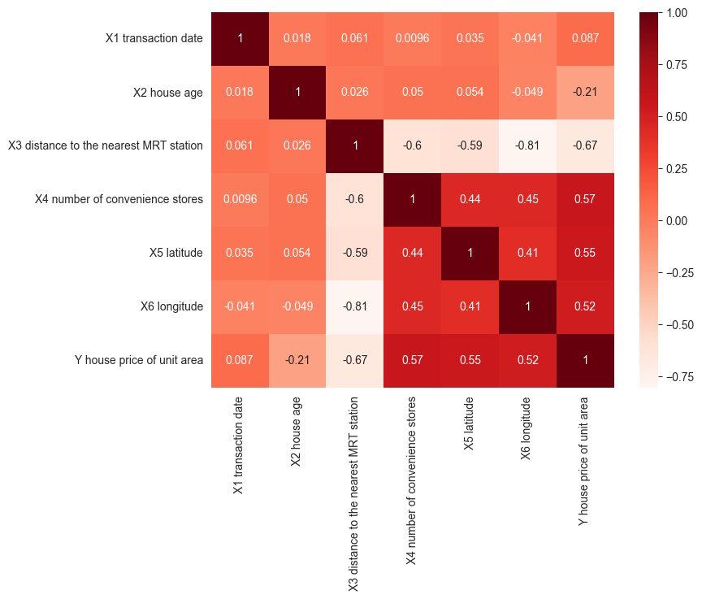

```python
plt.figure(figsize=(8,6))
sns.heatmap(df.drop(columns='No').corr(), annot=True, cmap='Reds')
plt.show()
```

**1. Describe qué información lees de esto.**

La matriz muestra la correlación lineal de Pearson entre cada par de variables. La fila/columna que nos interesa es la de `Y house price of unit area`, ya que nos dice qué tan asociada está cada variable con el precio.

**2. ¿Cuáles son las variables fuertemente correlacionadas?**

Con el precio, la correlación más fuerte es con $X_3$ (distancia a la estación de metro más cercana), con $r \approx -0.67$, es decir, una correlación negativa moderada-fuerte. Le siguen $X_4$ (número de tiendas de conveniencia, $r \approx 0.57$), $X_5$ (latitud, $r \approx 0.55$) y $X_6$ (longitud, $r \approx 0.52$). $X_1$ (fecha de transacción) y $X_2$ (edad de la casa) tienen correlaciones débiles con el precio ($r \approx 0.09$ y $r \approx -0.21$ respectivamente).

**3. ¿Te hacen sentido?**

Sí. Entre más lejos está una casa del metro, más barata tiende a ser (correlación negativa), lo cual es razonable porque la cercanía al transporte público suele encarecer la vivienda. Más tiendas de conveniencia cerca suele indicar una zona más urbanizada y con más servicios, de ahí la correlación positiva con el precio. Latitud y longitud correlacionan con el precio porque, en los datos, ciertas zonas de la ciudad (con determinada latitud/longitud) concentran las propiedades más caras; esto es una asociación geográfica, no una relación causal directa como la de la distancia al metro.

## Análisis exploratorio de datos (EDA)

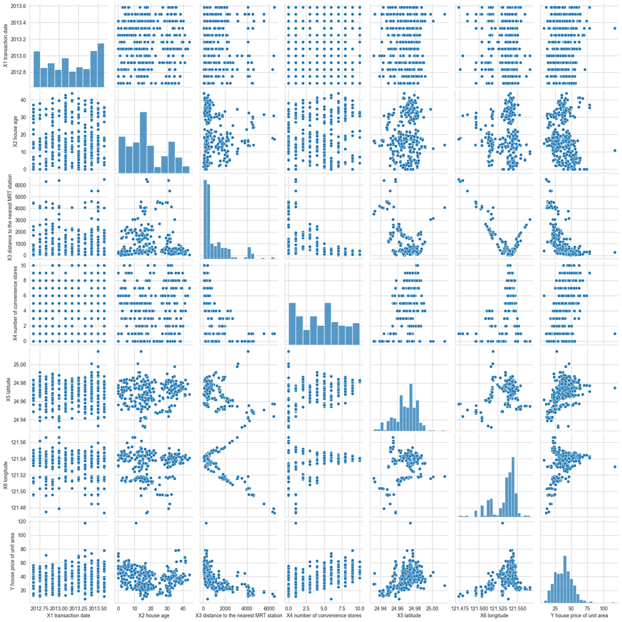

```python
sns.pairplot(df.drop(columns='No'))
plt.show()
```

**4. Con base en la correlación y estas gráficas, ¿qué variables pueden modelarse con una regresión lineal?**

$X_3$ (distancia a la estación de metro) es la que muestra el patrón más claramente lineal (decreciente) con el precio. $X_4$ (número de tiendas de conveniencia) también muestra una tendencia creciente, aunque al ser una variable discreta (0 a 10) su relación se ve más como franjas escalonadas que como una línea continua. $X_1$ y $X_2$ se ven como nubes de puntos bastante dispersas, sin un patrón lineal claro.

## Entrenando un modelo de regresión lineal

### Arrays X y y

Vamos a quitar la columna `No` (es solo un identificador) y el precio por unidad de área. La variable a predecir es el precio de la vivienda por unidad de área:

$$Y = \beta_0 + \beta_1 X_1 + \beta_2 X_2 + \beta_3 X_3 + \beta_4 X_4 + \beta_5 X_5 + \beta_6 X_6 + \varepsilon$$

```python
X = df.drop(columns=['No', 'Y house price of unit area'])

y = df['Y house price of unit area']
```

```python
print('X=', X.shape, '\ny=', y.shape)
```

```
X= (414, 6)
y= (414,)
```

## División de los datos: Entrenamiento y Prueba

Dividimos los datos en un conjunto de entrenamiento y uno de prueba. El modelo se ajusta con el conjunto de entrenamiento y se evalúa con el conjunto de prueba, que el modelo nunca ve durante el ajuste.

```python
X_train, X_test, y_train, y_test = train_test_split(X, y, test_size=0.3, random_state=101)
```

```python
X_train.shape
```

```
(289, 6)
```

```python
X_test.shape
```

```
(125, 6)
```

### Ajuste del modelo con LinearRegression()

`LinearRegression()` de scikit-learn resuelve internamente el mismo problema de mínimos cuadrados ordinarios (MCO) visto en clase, es decir, encuentra $\hat{\beta}$ que minimiza:

$$S(\beta) = \sum_{i=1}^n \left(y_i - \hat{y}_i\right)^2$$

cuya solución cerrada es $\hat{\beta} = (X^TX)^{-1}X^Ty$.

```python
model = LinearRegression()
```

```python
model.fit(X_train, y_train)
```

```
LinearRegression()
```

#### Evaluación del modelo

```python
model.intercept_
```

```
np.float64(-18595.055034519715)
```

```python
model.coef_
```

```
array([ 4.83926101e+00, -2.74749120e-01, -4.18860818e-03,  1.18123112e+00,
        2.42384317e+02,  2.33991349e+01])
```

```python
pd.DataFrame(model.coef_, X.columns, columns=['Coeficientes'])
```

|  | Coeficientes |
| --- | --- |
| X1 transaction date | 4.839261 |
| X2 house age | -0.274749 |
| X3 distance to the nearest MRT station | -0.004189 |
| X4 number of convenience stores | 1.181231 |
| X5 latitude | 242.384317 |
| X6 longitude | 23.399135 |

**5. Regresa a la pregunta 4, y ve si los coeficientes corresponden a la figura.**

Sí corresponden. $X_3$ (distancia al metro) tiene coeficiente negativo, consistente con la correlación negativa y la tendencia decreciente del pairplot. $X_4$ (tiendas de conveniencia) tiene coeficiente positivo, consistente con su correlación positiva. $X_2$ (edad de la casa) también sale negativo, en línea con su correlación negativa débil. $X_1$, $X_5$ y $X_6$ salen positivos, igual que su correlación con el precio, aunque su magnitud depende mucho de la escala de cada variable (por ejemplo, la latitud varía muy poco entre observaciones, así que su coeficiente es grande en valor absoluto para compensar esa escala pequeña).

**6. ¿Cómo se interpreta cada coeficiente?**

Cada $\beta_j$ representa el cambio esperado en el precio por unidad de área cuando $X_j$ aumenta una unidad, **manteniendo fijas las demás variables** (igual que interpretamos $\beta_1$ en regresión simple, pero ahora "a variables constantes"):

- $\beta_{X_1}$ (fecha de transacción): por cada año que avanza la transacción, el precio sube en promedio esa cantidad de unidades, manteniendo todo lo demás igual.
- $\beta_{X_2}$ (edad de la casa): por cada año adicional de antigüedad, el precio baja en promedio esa cantidad de unidades.
- $\beta_{X_3}$ (distancia a la estación de metro): por cada metro adicional de distancia al metro más cercano, el precio baja esa cantidad (pequeña porque la distancia se mide en metros, con valores de hasta varios miles).
- $\beta_{X_4}$ (tiendas de conveniencia cercanas): por cada tienda de conveniencia adicional en la zona, el precio sube esa cantidad de unidades.
- $\beta_{X_5}$ y $\beta_{X_6}$ (latitud y longitud): reflejan una prima de ubicación; como la latitud y la longitud varían muy poco en el dataset, no conviene interpretarlos como "mover un grado" sino como un efecto de la zona geográfica en la que está la propiedad.

Como en la Lección 1: $\beta_0$ es el precio esperado cuando todas las $X_j$ valen 0, algo que aquí no tiene sentido práctico (nadie tiene latitud/longitud 0), así que no lo interpretamos de forma literal.

### Predicciones del modelo

```python
y_pred = model.predict(X_test)
```

## Métricas de evaluación de la regresión

Usando la misma notación que en las diapositivas:

$$\text{MAE} = \frac{1}{n}\sum_{i=1}^n |y_i - \hat{y}_i|$$

$$\text{MSE} = \frac{1}{n}\sum_{i=1}^n (y_i - \hat{y}_i)^2$$

$$\text{RMSE} = \sqrt{\text{MSE}}$$

```python
MAE = metrics.mean_absolute_error(y_test, y_pred)
MSE = metrics.mean_squared_error(y_test, y_pred)
RMSE = np.sqrt(MSE)
```

```python
MAE
```

```
5.392293684756542
```

```python
MSE
```

```
46.21179783493614
```

```python
RMSE
```

```
np.float64(6.797925995105871)
```

El RMSE queda en las mismas unidades que $Y$ (precio por unidad de área), así que es el más fácil de comparar contra la variabilidad natural de los precios.

## Coeficiente de determinación $R^2$

Con la descomposición de varianza vista en la tabla ANOVA:

$$\text{SST} = \text{SSR} + \text{SSE}, \qquad R^2 = \frac{\text{SSR}}{\text{SST}} = 1 - \frac{\text{SSE}}{\text{SST}}$$

```python
y_mean = y_test.mean()

SST = np.sum((y_test - y_mean)**2)
SSE = np.sum((y_test - y_pred)**2)
SSR = SST - SSE

R2 = SSR / SST
R2
```

```
np.float64(0.6509058479986625)
```

```python
metrics.r2_score(y_test, y_pred)
```

```
0.6509058479986625
```

El modelo explica alrededor del 65% de la variabilidad del precio por unidad de área en el conjunto de prueba. No es un ajuste perfecto, pero tampoco despreciable considerando que el precio de una vivienda depende de muchos otros factores que no están en este dataset.

## Histograma de residuos

Además de las métricas de error, conviene revisar los residuos $y - \hat{y}$: si el modelo cumple los supuestos de la Lección 1, deberían verse aproximadamente normales y centrados en cero.

```python
test_residual = y_test - y_pred
```

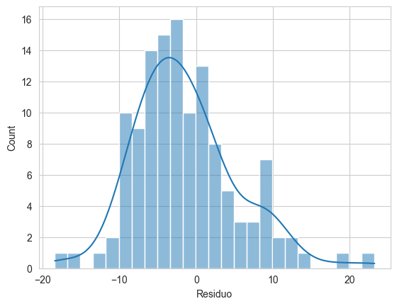

```python
sns.histplot(test_residual, bins=25, kde=True)
plt.xlabel('Residuo')
plt.show()
```

## Residuos vs. valores reales

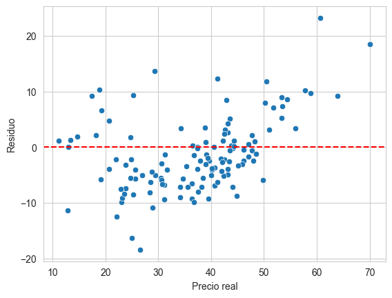

```python
sns.scatterplot(x=y_test, y=test_residual)
plt.axhline(y=0, color='r', ls='--')
plt.xlabel('Precio real')
plt.ylabel('Residuo')
plt.show()
```

## Conclusiones

- La variable más asociada al precio es la distancia a la estación de metro más cercana, seguida del número de tiendas de conveniencia cercanas y la ubicación (latitud/longitud).
- El modelo de regresión lineal múltiple explica cerca del 65% de la variabilidad del precio ($R^2 \approx 0.65$), con un error promedio (RMSE) de unas 6.8 unidades de precio.
- Como se vio en la Lección 1, correlación no implica causalidad: que latitud y longitud estén correlacionadas con el precio no significa que la ubicación geográfica "cause" el precio por sí misma, sino que refleja las zonas donde se concentran las propiedades más caras.